# Synthetic Breast Cancer Data Analysis

Xiaoying Ma

06/02/2026

# 1 Introduction

This report uses the **Synthetic Breast Cancer Dataset** to explore visual patterns related to breast cancer diagnosis. The dataset contains 600 observations, 11 variables describing cellular characteristics extracted from breast tissue samples. The outcome variable indicates whether a tumor is benign or malignant.

| variable # | Variable Name | Data Type | Description / Values |
| --- | --- | --- | --- |
| 1 | Sample_No | Numeric | Sample identification number |
| 2 | Thickness_of_Clump | Numeric | Thickness of cell clumps |
| 3 | Cell_Size_Uniformity | Numeric | Uniformity of cell size |
| 4 | Cell_Shape_Uniformity | Numeric | Uniformity of cell shap |
| 5 | Marginal_Adhesion | Numeric | Degree of cell adhesion |
| 6 | Single_Epithelial_Cell_Size | Numeric | Size of epithelial cells |
| 7 | Bare_Nuclei | Numeric | Presence of bare nuclei |
| 8 | Bland_Chromatin | Numeric | Chromatin texture |
| 9 | Normal_Nucleoli | Numeric | Prominence of nucleoli |
| 10 | Mitoses Numeric | Numeric | Abnormal cell growth |
| 11 | Outcome | Categorical | **Target variable** – No = Benign, Yes = Malignant |

The main practical questions are:

**Question 1**: Which cellular characteristics differ most between benign and malignant tumors?

**Question 2**: Which variables appear to be the strongest indicators of malignancy?

**Question 3**: How are the cytological characteristics related to one another?

All visualizations are created using Base R graphics only.

# 2 Data Preparation

The data set in this case study is relatively clean, we will only give two examples of data processing in the following.

```r
# library(readr)   # only for reading the CSV; all plots are base R

cancer <- read_csv("syntheticBreastCancerData.csv")

# Convert Outcome to a factor with clear labels
cancer$Outcome <- factor(cancer$Outcome,
                         levels = c("No", "Yes"),
                         labels = c("Benign", "Malignant"))

# Create a binned version of Thickness_of_Clump
cancer$Thickness_bin <- cut(cancer$Thickness_of_Clump,
                            breaks = c(-Inf, 3, 6, 8, Inf),
                            labels = c("Low", "Moderate", "High", "Very High"))

# Display structure of the dataset
str(cancer)
```

```
spc_tbl_ [600 × 12] (S3: spec_tbl_df/tbl_df/tbl/data.frame)
 $ Sample_No                  : num [1:600] 1 2 3 4 5 6 7 8 9 10 ...
 $ Thickness_of_Clump         : num [1:600] 6 6 3 7 6 8 3 4 4 6 ...
 $ Cell_Size_Uniformity       : num [1:600] 2 6 2 9 3 10 2 3 2 2 ...
 $ Cell_Shape_Uniformity      : num [1:600] 2 5 3 9 1 10 1 2 1 3 ...
 $ Marginal_Adhesion          : num [1:600] 2 6 1 2 4 9 1 2 2 1 ...
 $ Single_Epithelial_Cell_Size: num [1:600] 2 7 2 4 3 7 3 2 3 4 ...
 $ Bare_Nuclei                : num [1:600] 2 10 2 4 3 10 10 1 3 1 ...
 $ Bland_Chromatin            : num [1:600] 5 5 4 4 4 9 5 3 1 2 ...
 $ Normal_Nucleoli            : num [1:600] 1 2 2 7 3 9 2 2 3 2 ...
 $ Mitoses                    : num [1:600] 1 2 2 2 1 2 1 2 5 1 ...
 $ Outcome                    : Factor w/ 2 levels "Benign","Malignant": 1 1 1 1 1 2 1 1 1 1 ...
 $ Thickness_bin              : Factor w/ 4 levels "Low","Moderate",..: 2 2 1 3 2 3 1 2 2 2 ...
 - attr(*, "spec")=
  .. cols(
  ..   Sample_No = col_double(),
  ..   Thickness_of_Clump = col_double(),
  ..   Cell_Size_Uniformity = col_double(),
  ..   Cell_Shape_Uniformity = col_double(),
  ..   Marginal_Adhesion = col_double(),
  ..   Single_Epithelial_Cell_Size = col_double(),
  ..   Bare_Nuclei = col_double(),
  ..   Bland_Chromatin = col_double(),
  ..   Normal_Nucleoli = col_double(),
  ..   Mitoses = col_double(),
  ..   Outcome = col_character()
  .. )
 - attr(*, "problems")=<externalptr>
```

# 3 Practical Questions and Visualizations

For illustrative purpose, we choose three questions demonstrate ideas of visual exploratory analysis in this section.

## 3.1 Cellular Characteristics by Diagnosis

**Question 1**: Which cellular characteristics differ most between benign and malignant tumors?

**Visualization 1**: Boxplots of Clump Thickness and Cell Size Uniformity

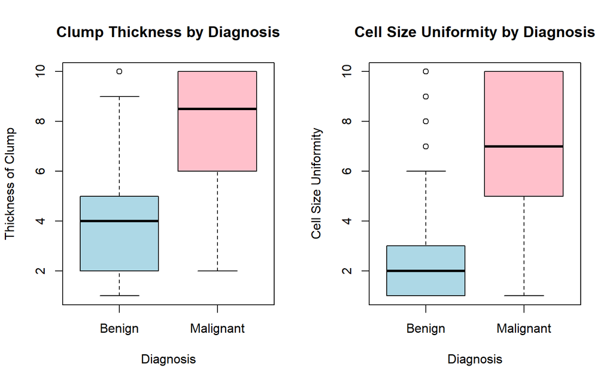

```r
par(mfrow = c(1, 2))

boxplot(Thickness_of_Clump ~ Outcome,
        data = cancer,
        col = c("lightblue", "pink"),
        main = "Clump Thickness by Diagnosis",
        xlab = "Diagnosis",
        ylab = "Thickness of Clump")

boxplot(Cell_Size_Uniformity ~ Outcome,
        data = cancer,
        col = c("lightblue", "pink"),
        main = "Cell Size Uniformity by Diagnosis",
        xlab = "Diagnosis",
        ylab = "Cell Size Uniformity")
```

```r
par(mfrow = c(1, 1))
```

**Observed Patterns**:

Malignant tumors tend to have higher clump thickness and greater cell size uniformity scores. Benign tumors usually have lower values and less variation.

**Analytic Action**:

These variables should be considered important diagnostic features because they show clear separation between benign and malignant groups.

## 3.2 Strongest Indicators of Malignancy.

**Question 2**: Which variables appear to be the strongest indicators of malignancy?

**Visualization 2**: Density Plot of Bare Nuclei

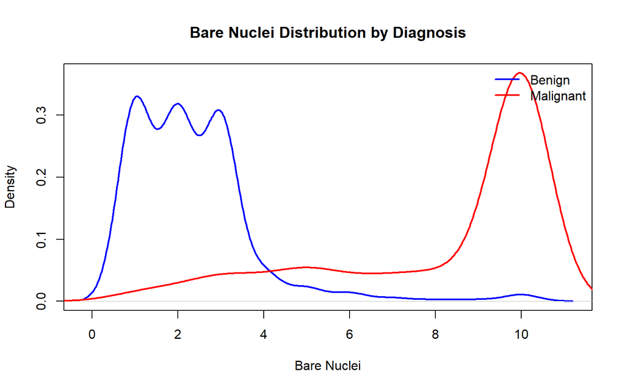

```r
benign <- cancer$Bare_Nuclei[cancer$Outcome == "Benign"]
malignant <- cancer$Bare_Nuclei[cancer$Outcome == "Malignant"]

d_benign <- density(benign, na.rm = TRUE)
d_malignant <- density(malignant, na.rm = TRUE)

plot(d_benign,
     col = "blue",
     lwd = 2,
     main = "Bare Nuclei Distribution by Diagnosis",
     xlab = "Bare Nuclei",
     ylim = c(0, max(d_benign$y, d_malignant$y)))

lines(d_malignant, col = "red", lwd = 2)

legend("topright",
       legend = c("Benign", "Malignant"),
       col = c("blue", "red"),
       lwd = 2,
       bty = "n")
```

**Visualization 3**: Boxplots of Bare Nuclei and Normal Nucleoli

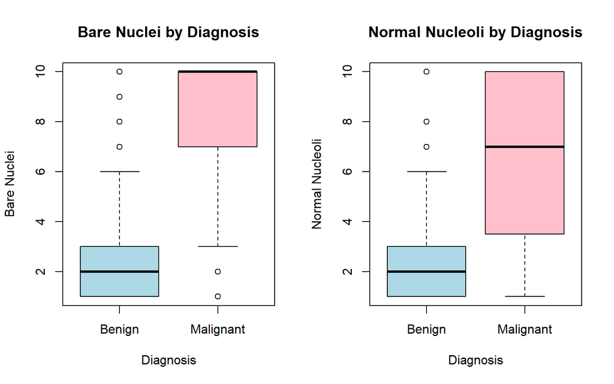

```r
par(mfrow = c(1, 2))

boxplot(Bare_Nuclei ~ Outcome,
        data = cancer,
        col = c("lightblue", "pink"),
        main = "Bare Nuclei by Diagnosis",
        xlab = "Diagnosis",
        ylab = "Bare Nuclei")

boxplot(Normal_Nucleoli ~ Outcome,
        data = cancer,
        col = c("lightblue", "pink"),
        main = "Normal Nucleoli by Diagnosis",
        xlab = "Diagnosis",
        ylab = "Normal Nucleoli")
```

```r
par(mfrow = c(1, 1))
```

**Observed Patterns**:

Malignant tumors generally have higher Bare Nuclei and Normal Nucleoli values. These variables show strong separation between benign and malignant samples.

**Analytic Action**:

Bare Nuclei and Normal Nucleoli may be strong predictors of malignancy and should be included in future predictive modeling.

## 3.3 Relationships Among Cytological Features

**Question 3**: How are the cytological characteristics related to one another?

**Visualization 4**: Correlation Heatmap

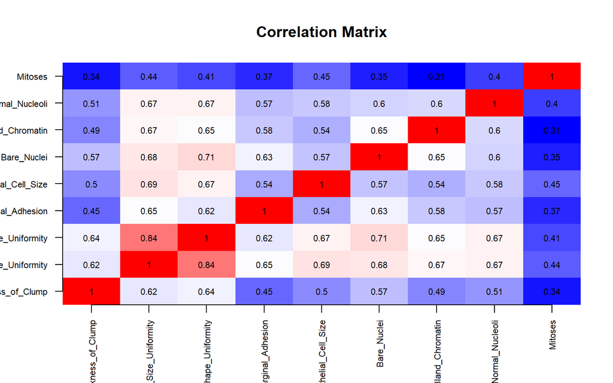

```r
num_vars <- cancer[, c(
  "Thickness_of_Clump",
  "Cell_Size_Uniformity",
  "Cell_Shape_Uniformity",
  "Marginal_Adhesion",
  "Single_Epithelial_Cell_Size",
  "Bare_Nuclei",
  "Bland_Chromatin",
  "Normal_Nucleoli",
  "Mitoses"
)]

cor_mat <- cor(num_vars, use = "complete.obs")

n <- ncol(cor_mat)

palette <- colorRampPalette(c("blue", "white", "red"))(100)

image(1:n,
      1:n,
      cor_mat,
      col = palette,
      axes = FALSE,
      main = "Correlation Matrix",
      xlab = "",
      ylab = "")

axis(1,
     at = 1:n,
     labels = colnames(cor_mat),
     las = 2,
     cex.axis = 0.7)

axis(2,
     at = 1:n,
     labels = colnames(cor_mat),
     las = 2,
     cex.axis = 0.7)

text(expand.grid(x = 1:n, y = 1:n),
     labels = round(cor_mat, 2),
     cex = 0.7)
```

**Observed Patterns**:

Cell Size Uniformity and Cell Shape Uniformity are strongly positively related. Other abnormal cellular features, such as Bare Nuclei, Bland Chromatin, and Normal Nucleoli, also tend to increase together.

**Analytic Action**:

The correlation pattern suggests that malignant tumors often show multiple abnormal cellular characteristics at the same time.

# 4 Summary and Recommendations

This report explored visual patterns in the Synthetic Breast Cancer Dataset using Base R graphics.

First, the boxplots showed that malignant tumors generally have higher values for Thickness of Clump and Cell Size Uniformity. These characteristics indicate abnormal cell growth and variation.

Second, the density plot and boxplots showed that Bare Nuclei and Normal Nucleoli separate benign and malignant tumors clearly. These variables appear to be strong indicators of malignancy.

Finally, the correlation heatmap showed that many cytological variables are positively correlated. This means that abnormal cell features often occur together rather than independently.

Overall, the analysis suggests that cell size uniformity, cell shape uniformity, bare nuclei, and normal nucleoli are important features for identifying malignant breast cancer cases.